# SSB Analyses

Matthew Pottinger & Sarah Swiston

2025-11-13

## Setup

Making things into functions so we don’t have to rewrite so much code

```r
do_mcmc <- function(f) {
  # File names
  analysis_name <- paste0(ANALYSIS, "_", SSBTYPE, "_", HYPOTHESIS, "_", tree_number, "_", NUMBER)
  out_file <- paste0("output/", analysis_name, ".log.csv")
  summary_file <- paste0("output/", analysis_name, ".sum.txt")

  # Read in data
  columns <- c("Species", all.vars(f))
  data_subset <- data[, columns]
  # Removes incomplete cases
  data_subset <- data_subset[complete.cases(data_subset), ]

  # Running MCMCglmm
  MCMCanalysis <- MCMCglmm::MCMCglmm(f,
    random = ~Species,
    family = "categorical",
    ginverse = list(Species = inv.phylo),
    prior = prior,
    data = data_subset,
    nitt = NITT,
    burnin = BURNIN,
    thin = THIN,
    verbose = FALSE
  )

  write.csv(MCMCanalysis$Sol, out_file, row.names = FALSE, quote = FALSE)
  out <- capture.output(
    cat(paste0("ESS: ", ess(MCMCanalysis$Sol), "\n")),
    print(summary(MCMCanalysis$Sol))
  )
  write(out, summary_file)
}
```

```r
do_pagel <- function() {
  # File names
  analysis_name <- paste0(ANALYSIS, "_", SSBTYPE, "_", VARIABLE, "_", tree_number, "_", NUMBER)
  summary_file <- paste0("output/", analysis_name, ".sum.txt")

  # Read in data
  columns <- c("Species", SSBTYPE, VARIABLE)
  data_subset <- data[, columns]
  # Removes incomplete cases
  data_subset <- data_subset[complete.cases(data_subset), ]
  phy_subset <- ape::keep.tip(phy, data_subset$Species)

  # Assign species names
  SSB <- setNames(data_subset[[SSBTYPE]], data_subset$Species)
  VAR <- setNames(data_subset[[VARIABLE]], data_subset$Species)

  write(paste0("Pagel's Directional Test for ", SSBTYPE, " and ", VARIABLE), summary_file)
  write("--------------------", summary_file, append = TRUE)

  # Fit models where SSB and NAC are totally independent or dependent
  fit_SSB_VAR <- phytools::fitPagel(phy_subset, SSB, VAR)
  out1 <- capture.output(print(fit_SSB_VAR))
  write(paste0("Both Independent or Dependent"), summary_file, append = TRUE)
  write(out1, summary_file, append = TRUE)
  write("--------------------", summary_file, append = TRUE)

  # Fit model where SSB depends on NAC
  fit_SSB <- phytools::fitPagel(phy_subset, SSB, VAR, dep.var = "x")
  out2 <- capture.output(print(fit_SSB))
  write(paste0("Dependent ", SSBTYPE), summary_file, append = TRUE)
  write(out2, summary_file, append = TRUE)
  write("--------------------", summary_file, append = TRUE)

  # Fit model where NAC depends on SSB
  fit_VAR <- phytools::fitPagel(phy_subset, SSB, VAR, dep.var = "y")
  out3 <- capture.output(print(fit_VAR))
  write(paste0("Dependent ", VARIABLE), summary_file, append = TRUE)
  write(out3, summary_file, append = TRUE)
  write("--------------------", summary_file, append = TRUE)

  # Comparing the goodness of all 4 models using AIC
  aic <- setNames(
    c(
      fit_SSB_VAR$independent.AIC,
      fit_SSB$dependent.AIC,
      fit_VAR$dependent.AIC,
      fit_SSB_VAR$dependent.AIC
    ),
    c("independent", "dependent SSB", paste0("dependent ", VARIABLE), paste0("dependent SSB & ", VARIABLE))
  )
  out4 <- capture.output(print(aic))
  out5 <- capture.output(print(aic.w(aic)))
  write(paste0("AIC"), summary_file, append = TRUE)
  write(out4, summary_file, append = TRUE)
  write(paste0("Weights"), summary_file, append = TRUE)
  write(out5, summary_file, append = TRUE)
}
```

## Dataset

```
##  [1] "GP = Gestation Period (m)"
##  [2] "BM = Birth Mass (kg)"
##  [3] "AFM = Adult Female Mass (kg)"
##  [4] "MR = Birth Mass to Maternal Mass Ratio"
##  [5] "RDM = Radically Dimorphic Morphology?"
##  [6] "TSP = Typically Single Progeny?"
##  [7] "PC = Progeny Count"
##  [8] "FWA = Fully Weaned Age (m)"
##  [9] "FAM = Female Age of Maturity (m)"
## [10] "MAM = Male age of Maturity (m)"
## [11] "NB = Nonseasonal Breeding?"
## [12] "SDT = Some Degree of Territoriality?"
## [13] "GL = Group Living (Beyond families)?"
## [14] "SPI = Strong Paternal Involvement?"
## [15] "NAC = Notable Alloparental Care (Beyond Alerts)?"
```

[output cut: 18 more lines]

```
## [1] "SOL = Solitary"
## [2] "MOP = Monogamous Pairs"
## [3] "HAR = Harems"
## [4] "HBG = Harems with Bachelor Groups"
## [5] "MMG = Multimale-Multifemale Groups"
## [6] "MBG = Multimale-Multifemale with Bachelor Groups"
## [7] "FEG = Female Exclusive Groups"
## [8] "SSG = Segrated Sex Groups"
## [9] "HVG = Highly Variable Group Structure"
```

```r
# This code chunk reads our giant list of trees and combines them to make one "best" tree
# We want to see this code (echo=TRUE), but we don't want to run it every time we do our analyses (it takes a while)
ANALYSIS <- "MCMCTREE"
if (USEGLOBAL) {
  set_global()
}
if (ANALYSIS == "MCCTREE") {
  trees <- ape::read.nexus("new_phylogeny.nex")
  phy_mcc <- phangorn::maxCladeCred(trees) # Generates a maximum clade credibility (best) tree from the 1000 trees
  cat(paste0("Is Ultrametric? ", ape::is.ultrametric(phy_mcc)))
  cat(paste0("Is Bifurcating? ", castor::is_bifurcating(phy_mcc)))
  n_taxa <- length(phy_mcc$tip.label) # Gets the number of species from looking at the tip labels
  phy_mcc$node.label <- c((n_taxa + 1):(n_taxa + phy_mcc$Nnode)) # Gives number labels to nodes
  ape::write.tree(phy_mcc, "new_mcc_tree.txt") # Saves this tree to a file called "mcc_tree.txt"
}
```

[output not shown]

Here is the phylogeny that we are using, only including taxa which are in the species dataset.

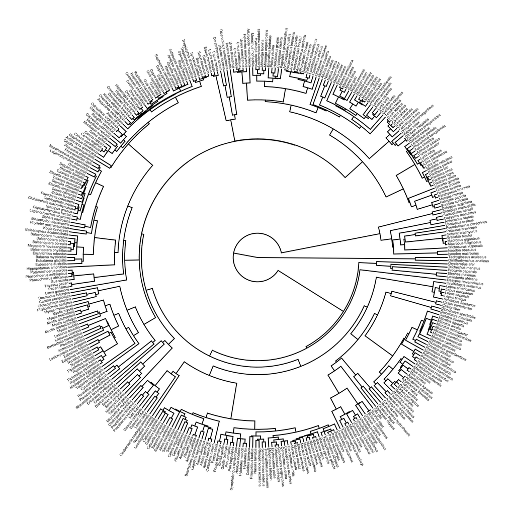

## Maternal Investment

### Hypothesis:

Species with greater maternal investment need to allocate more resources to reproductively fruitful mating, and are thus less likely to exhibit SSB.

Covariates:

↑ in factor associated with ↑ in SSB: Alloparental Care (NAC), Progeny Count (PC), Paternal Investment (SPI)

↑ in factor associated with ↓ in SSB: Gestation Period (GP), Wean Age (FWA), Birth Mass to Maternal Mass Ratio (MR), Typically Single Progeny (TSP)

#### MCMCGLMM

```r
# Runs MCMCglmm for all our Maternal investment variables. Individual binary variables each get their own suite of pagels below.
ANALYSIS <- "MCMCGLMM"
HYPOTHESIS <- "MI"
SSBTYPE <- "SSB"
if (USEGLOBAL) {
  set_global()
}
f <- SSB ~ NAC + PC + SPI + GP + FWA + MR + TSP + 1
if (ANALYSIS == "MCMCGLMM" & HYPOTHESIS == "MI" & SSBTYPE == "SSB") {
  do_mcmc(f)
}
```

```
## ESS: 6
##
## Iterations = 11:100
## Thinning interval = 1
## Number of chains = 1
## Sample size per chain = 90
##
## 1. Empirical mean and standard deviation for each variable,
##    plus standard error of the mean:
##
##                 Mean      SD Naive SE Time-series SE
## (Intercept)  0.15935 0.63231 0.066651       0.089847
## NAC1         0.48995 0.31121 0.032804       0.122264
## PC          -0.38376 0.11928 0.012574       0.043162
## SPI1        -1.06362 0.42756 0.045068       0.191465
## GP           0.02086 0.03596 0.003791       0.009467
## FWA          0.02769 0.01994 0.002102       0.007651
## MR          -1.55273 1.89480 0.199729       0.625811
## TSP1        -0.17790 0.31096 0.032778       0.075428
##
## 2. Quantiles for each variable:
##
##                 2.5%       25%      50%       75%    97.5%
## (Intercept) -1.05576 -0.205912  0.19003  0.652389  1.21529
## NAC1        -0.16438  0.290615  0.49817  0.682983  1.01743
## PC          -0.57880 -0.476840 -0.39100 -0.303479 -0.15087
## SPI1        -1.79337 -1.376794 -1.07107 -0.786479 -0.16660
## GP          -0.04204 -0.001204  0.01986  0.041527  0.09139
## FWA         -0.01198  0.017587  0.02868  0.042497  0.05950
## MR          -5.31476 -2.692185 -1.51001 -0.224420  2.02004
## TSP1        -0.82198 -0.344467 -0.17653  0.002624  0.41414
```

```r
# Runs MCMCglmm for all our Maternal investment variables. Individual binary variables each get their own suite of pagels below.
ANALYSIS <- "MCMCGLMM"
HYPOTHESIS <- "MI"
SSBTYPE <- "FSSB"
if (USEGLOBAL) {
  set_global()
}
f <- FSSB ~ NAC + PC + SPI + GP + FWA + MR + TSP + 1
if (ANALYSIS == "MCMCGLMM" & HYPOTHESIS == "MI" & SSBTYPE == "FSSB") {
  do_mcmc(f)
}
```

```
## ESS: 5
##
## Iterations = 11:100
## Thinning interval = 1
## Number of chains = 1
## Sample size per chain = 90
##
## 1. Empirical mean and standard deviation for each variable,
##    plus standard error of the mean:
##
##                  Mean      SD Naive SE Time-series SE
## (Intercept) -1.123984 0.81470 0.085877       0.207391
## NAC1         0.732387 0.19580 0.020639       0.035030
## PC          -0.259408 0.12177 0.012836       0.041073
## SPI1        -0.676508 0.24764 0.026103       0.062191
## GP           0.101936 0.04404 0.004642       0.011060
## FWA          0.006352 0.01473 0.001553       0.005453
## MR          -3.437621 1.83669 0.193604       0.567087
## TSP1        -0.312285 0.46682 0.049207       0.280502
##
## 2. Quantiles for each variable:
##
##                 2.5%       25%       50%      75%    97.5%
## (Intercept) -2.85044 -1.523818 -1.035275 -0.61993  0.19309
## NAC1         0.37545  0.607735  0.734906  0.88196  1.08530
## PC          -0.45087 -0.350419 -0.271074 -0.19526  0.01416
## SPI1        -1.14051 -0.842828 -0.713439 -0.50327 -0.18536
## GP           0.03094  0.067554  0.105243  0.13326  0.18248
## FWA         -0.01971 -0.003814  0.007443  0.01401  0.03319
## MR          -6.94831 -4.656909 -3.416677 -2.04886 -0.17080
## TSP1        -1.16236 -0.662129 -0.245896 -0.03032  0.57410
```

```r
# Runs MCMCglmm for all our Maternal investment variables. Individual binary variables each get their own suite of pagels below.
ANALYSIS <- "MCMCGLMM"
HYPOTHESIS <- "MI"
SSBTYPE <- "MSSB"
if (USEGLOBAL) {
  set_global()
}
f <- MSSB ~ NAC + PC + SPI + GP + FWA + MR + TSP + 1
if (ANALYSIS == "MCMCGLMM" & HYPOTHESIS == "MI" & SSBTYPE == "MSSB") {
  do_mcmc(f)
}
```

```
## ESS: 3
##
## Iterations = 11:100
## Thinning interval = 1
## Number of chains = 1
## Sample size per chain = 90
##
## 1. Empirical mean and standard deviation for each variable,
##    plus standard error of the mean:
##
##                 Mean      SD Naive SE Time-series SE
## (Intercept) -0.20309 0.87348 0.092073        0.38303
## NAC1         0.51323 0.20852 0.021980        0.05723
## PC          -0.28284 0.07324 0.007720        0.01472
## SPI1        -0.97404 0.28951 0.030517        0.08512
## GP           0.04006 0.07442 0.007844        0.04643
## FWA          0.02694 0.02231 0.002352        0.02204
## MR          -0.20236 2.58286 0.272257        1.66155
## TSP1        -0.20299 0.33168 0.034962        0.10236
##
## 2. Quantiles for each variable:
##
##                 2.5%       25%      50%      75%    97.5%
## (Intercept) -1.80807 -0.787882 -0.07212  0.41458  1.40429
## NAC1         0.12926  0.355210  0.53993  0.63967  0.91728
## PC          -0.41320 -0.337809 -0.28261 -0.23854 -0.15967
## SPI1        -1.42464 -1.173181 -0.97980 -0.81962 -0.32723
## GP          -0.10105 -0.008632  0.05868  0.09799  0.15964
## FWA         -0.01304  0.006944  0.02919  0.04755  0.06432
## MR          -4.42390 -2.353225 -0.10207  1.86891  4.09803
## TSP1        -0.75645 -0.434898 -0.26659  0.07746  0.43070
```

#### Pagel’s Directional Test

##### NAC

SSB vs. NAC

```r
ANALYSIS <- "PAGEL"
VARIABLE <- "NAC"
SSBTYPE <- "SSB"
if (USEGLOBAL) {
  set_global()
}
if (ANALYSIS == "PAGEL" & VARIABLE == "NAC" & SSBTYPE == "SSB") {
  do_pagel()
}
```

```
## AIC
##         independent       dependent SSB       dependent NAC dependent SSB & NAC
##            856.3443            856.9250            854.4898            857.5419
## Weights
##         independent       dependent SSB       dependent NAC dependent SSB & NAC
##           0.2072523           0.1550251           0.5238397           0.1138829
```

FSSB vs. NAC

```r
ANALYSIS <- "PAGEL"
VARIABLE <- "NAC"
SSBTYPE <- "FSSB"
if (USEGLOBAL) {
  set_global()
}
if (ANALYSIS == "PAGEL" & VARIABLE == "NAC" & SSBTYPE == "FSSB") {
  do_pagel()
}
```

```
## AIC
##         independent       dependent SSB       dependent NAC dependent SSB & NAC
##            786.5578            779.3010            768.4563            764.6815
## Weights
##         independent       dependent SSB       dependent NAC dependent SSB & NAC
##          0.00001542          0.00058063          0.13146225          0.86794170
```

MSSB vs. NAC

```r
ANALYSIS <- "PAGEL"
VARIABLE <- "NAC"
SSBTYPE <- "MSSB"
if (USEGLOBAL) {
  set_global()
}
if (ANALYSIS == "PAGEL" & VARIABLE == "NAC" & SSBTYPE == "MSSB") {
  do_pagel()
}
```

```
## AIC
##         independent       dependent SSB       dependent NAC dependent SSB & NAC
##            844.2232            844.5203            841.5144            845.2784
## Weights
##         independent       dependent SSB       dependent NAC dependent SSB & NAC
##          0.15806844          0.13624903          0.61241627          0.09326626
```

##### SPI

SSB vs. SPI

```r
ANALYSIS <- "PAGEL"
VARIABLE <- "SPI"
SSBTYPE <- "SSB"
if (USEGLOBAL) {
  set_global()
}
if (ANALYSIS == "PAGEL" & VARIABLE == "SPI" & SSBTYPE == "SSB") {
  do_pagel()
}
```

```
## AIC
##         independent       dependent SSB       dependent SPI dependent SSB & SPI
##            746.7418            749.9391            749.3105            753.1325
## Weights
##         independent       dependent SSB       dependent SPI dependent SSB & SPI
##          0.65791491          0.13301018          0.18213148          0.02694342
```

FSSB vs. SPI

```r
ANALYSIS <- "PAGEL"
VARIABLE <- "SPI"
SSBTYPE <- "FSSB"
if (USEGLOBAL) {
  set_global()
}
if (ANALYSIS == "PAGEL" & VARIABLE == "SPI" & SSBTYPE == "FSSB") {
  do_pagel()
}
```

```
## AIC
##         independent       dependent SSB       dependent SPI dependent SSB & SPI
##            676.0571            679.2705            678.9050            676.0523
## Weights
##         independent       dependent SSB       dependent SPI dependent SSB & SPI
##          0.40921993          0.08206550          0.09852073          0.41019385
```

MSSB vs. SPI

```r
ANALYSIS <- "PAGEL"
VARIABLE <- "SPI"
SSBTYPE <- "MSSB"
if (USEGLOBAL) {
  set_global()
}
if (ANALYSIS == "PAGEL" & VARIABLE == "SPI" & SSBTYPE == "MSSB") {
  do_pagel()
}
```

```
## AIC
##         independent       dependent SSB       dependent SPI dependent SSB & SPI
##            734.4604            736.2513            737.3494            739.8912
## Weights
##         independent       dependent SSB       dependent SPI dependent SSB & SPI
##          0.58464058          0.23877902          0.13789056          0.03868984
```

##### TSP

SSB vs. TSP

```r
ANALYSIS <- "PAGEL"
VARIABLE <- "TSP"
SSBTYPE <- "SSB"
if (USEGLOBAL) {
  set_global()
}
if (ANALYSIS == "PAGEL" & VARIABLE == "TSP" & SSBTYPE == "SSB") {
  do_pagel()
}
```

```
## AIC
##         independent       dependent SSB       dependent TSP dependent SSB & TSP
##            705.8974            688.6727            699.5265            687.1182
## Weights
##         independent       dependent SSB       dependent TSP dependent SSB & TSP
##          0.00005718          0.31446075          0.00138258          0.68409949
```

FSSB vs. TSP

```r
ANALYSIS <- "PAGEL"
VARIABLE <- "TSP"
SSBTYPE <- "FSSB"
if (USEGLOBAL) {
  set_global()
}
if (ANALYSIS == "PAGEL" & VARIABLE == "TSP" & SSBTYPE == "FSSB") {
  do_pagel()
}
```

```
## AIC
##         independent       dependent SSB       dependent TSP dependent SSB & TSP
##            636.3420            626.3909            640.0172            627.0098
## Weights
##         independent       dependent SSB       dependent TSP dependent SSB & TSP
##          0.00396399          0.57410177          0.00063106          0.42130318
```

MSSB vs. TSP

```r
ANALYSIS <- "PAGEL"
VARIABLE <- "TSP"
SSBTYPE <- "MSSB"
if (USEGLOBAL) {
  set_global()
}
if (ANALYSIS == "PAGEL" & VARIABLE == "TSP" & SSBTYPE == "MSSB") {
  do_pagel()
}
```

```
## AIC
##         independent       dependent SSB       dependent TSP dependent SSB & TSP
##            693.8563            677.1412            686.6910            675.3180
## Weights
##         independent       dependent SSB       dependent TSP dependent SSB & TSP
##          0.00006709          0.28596346          0.00241315          0.71155630
```

## Sociality

### Hypothesis 1:

Social species whose group structure involves increased time spent exclusively with the same sex will route more sexual behavior to same-sex interactions.

Tested covariates:

↑ in group type associated with ↑ in SSB: MBG, HBG, FEG, SSG

#### MCMCGLMM

```r
# Runs MCMCglmm for all our Sociality variables.
ANALYSIS <- "MCMCGLMM"
HYPOTHESIS <- "MGS"
SSBTYPE <- "SSB"
if (USEGLOBAL) {
  set_global()
}
f <- SSB ~ MGS + 1
if (ANALYSIS == "MCMCGLMM" & HYPOTHESIS == "MGS" & SSBTYPE == "SSB") {
  do_mcmc(f)
}
```

```
## ESS: 7
##
## Iterations = 11:100
## Thinning interval = 1
## Number of chains = 1
## Sample size per chain = 90
##
## 1. Empirical mean and standard deviation for each variable,
##    plus standard error of the mean:
##
##                Mean     SD Naive SE Time-series SE
## (Intercept) -2.0005 1.0424  0.10988         0.2940
## MGSHAR       1.2282 0.7030  0.07410         0.1516
## MGSHBG       2.9696 0.9314  0.09818         0.2709
## MGSMBG       2.3256 0.8803  0.09279         0.2636
## MGSMMG       1.9575 0.8547  0.09010         0.2807
## MGSMOP       0.3944 0.8395  0.08850         0.3244
## MGSSO        1.2270 0.7114  0.07499         0.2019
## MGSSSG       3.0874 0.8368  0.08821         0.2226
## MGSVGS       6.7924 1.4298  0.15071         0.4823
##
## 2. Quantiles for each variable:
##
##                2.5%      25%     50%     75%   97.5%
## (Intercept) -3.7021 -2.78987 -2.0118 -1.3060 -0.1311
## MGSHAR      -0.2136  0.72899  1.2477  1.7679  2.3986
## MGSHBG       1.1317  2.24669  3.0288  3.7030  4.5181
## MGSMBG       0.8283  1.65768  2.3553  3.0612  3.8637
## MGSMMG       0.5563  1.19450  2.0806  2.6187  3.4812
## MGSMOP      -1.3780 -0.09069  0.4207  0.8053  2.1578
## MGSSO       -0.1021  0.61499  1.2347  1.7653  2.5955
## MGSSSG       1.5558  2.50287  3.1057  3.5503  5.0204
## MGSVGS       4.1095  5.95948  6.7538  7.8260  9.3276
```

```r
# Runs MCMCglmm for all our Sociality variables.
ANALYSIS <- "MCMCGLMM"
HYPOTHESIS <- "MGS"
SSBTYPE <- "FSSB"
if (USEGLOBAL) {
  set_global()
}
f <- FSSB ~ MGS + 1
if (ANALYSIS == "MCMCGLMM" & HYPOTHESIS == "MGS" & SSBTYPE == "FSSB") {
  do_mcmc(f)
}
```

```
## ESS: 4
##
## Iterations = 11:100
## Thinning interval = 1
## Number of chains = 1
## Sample size per chain = 90
##
## 1. Empirical mean and standard deviation for each variable,
##    plus standard error of the mean:
##
##                 Mean     SD Naive SE Time-series SE
## (Intercept) -1.31519 1.0066  0.10610         0.2867
## MGSHAR       0.66724 0.5732  0.06042         0.1783
## MGSHBG       1.20911 0.6943  0.07319         0.3059
## MGSMBG       0.56584 0.9139  0.09633         0.4646
## MGSMMG       0.43984 0.6034  0.06361         0.1922
## MGSMOP      -1.75561 0.7212  0.07602         0.2400
## MGSSO       -0.43571 0.5151  0.05430         0.1715
## MGSSSG      -0.39735 0.5369  0.05659         0.1698
## MGSVGS      -0.02028 0.9514  0.10028         0.3218
##
## 2. Quantiles for each variable:
##
##                2.5%      25%     50%     75%   97.5%
## (Intercept) -3.2138 -2.06451 -1.2330 -0.5484  0.2870
## MGSHAR      -0.2349  0.22975  0.6149  1.1154  1.8697
## MGSHBG      -0.1249  0.77361  1.2654  1.6653  2.4683
## MGSMBG      -1.1432 -0.07414  0.5320  1.2469  2.2978
## MGSMMG      -0.6071  0.04950  0.4725  0.7247  1.7806
## MGSMOP      -2.9859 -2.19590 -1.6677 -1.3513 -0.4717
## MGSSO       -1.3807 -0.76271 -0.4306 -0.2060  0.6241
## MGSSSG      -1.2847 -0.78784 -0.4438 -0.1416  0.8009
## MGSVGS      -1.5482 -0.67197 -0.1187  0.4805  2.2856
```

```r
# Runs MCMCglmm for all our Sociality variables.
ANALYSIS <- "MCMCGLMM"
HYPOTHESIS <- "MGS"
SSBTYPE <- "MSSB"
if (USEGLOBAL) {
  set_global()
}
f <- MSSB ~ MGS + 1
if (ANALYSIS == "MCMCGLMM" & HYPOTHESIS == "MGS" & SSBTYPE == "MSSB") {
  do_mcmc(f)
}
```

```
## ESS: 3
##
## Iterations = 11:100
## Thinning interval = 1
## Number of chains = 1
## Sample size per chain = 90
##
## 1. Empirical mean and standard deviation for each variable,
##    plus standard error of the mean:
##
##                Mean     SD Naive SE Time-series SE
## (Intercept) -0.6908 1.0311  0.10869         0.5026
## MGSHAR      -0.4779 0.7406  0.07807         0.2656
## MGSHBG       1.6430 1.4013  0.14771         0.9160
## MGSMBG       1.0697 0.7657  0.08071         0.3240
## MGSMMG       0.3061 0.8169  0.08611         0.4673
## MGSMOP      -0.8378 0.8071  0.08507         0.4239
## MGSSO       -0.2849 0.8605  0.09070         0.5578
## MGSSSG       1.0348 0.9564  0.10081         0.5591
## MGSVGS       3.2971 1.6983  0.17902         1.3059
##
## 2. Quantiles for each variable:
##
##                2.5%     25%     50%      75%  97.5%
## (Intercept) -2.9435 -1.4005 -0.5536  0.08955 0.8624
## MGSHAR      -1.8521 -0.9727 -0.5273 -0.01370 0.8917
## MGSHBG      -0.3332  0.2283  1.9221  2.82923 3.8037
## MGSMBG      -0.2486  0.4666  0.9887  1.52808 2.5944
## MGSMMG      -1.0140 -0.3306  0.3270  0.93019 1.6144
## MGSMOP      -2.0495 -1.3275 -1.0580 -0.41989 0.7795
## MGSSO       -1.7123 -0.9170 -0.3394  0.28469 1.2832
## MGSSSG      -0.5244  0.4213  0.9547  1.85865 2.6842
## MGSVGS       0.7357  1.7342  3.3937  4.95864 5.8516
```

### Hypothesis 2:

Territorial animals are more likely to exhibit SSB as a means of mitigating the risk of fatal conspecific violence.

Tested covariates:

↑ in factor associated with ↑ in SSB: Territoriality

Note: The Nature paper that plotted out the phylogeny of SSB demonstrated that SSB often evolves subsequently to male adulticide, which they attributed to SSB potentially acting as a means of mitigation that allows for aggression release without necessitating more violence. This hypothesis is trying to build on that, which is why it doesn’t match the “Darwinian Paradox” approach of the others.

#### MCMCGLMM

```r
# Runs MCMCglmm for all our Territoriality variables. Individual binary variables each get their own suite of pagels below.
ANALYSIS <- "MCMCGLMM"
HYPOTHESIS <- "SDT"
SSBTYPE <- "SSB"
if (USEGLOBAL) {
  set_global()
}
f <- SSB ~ SDT + 1
if (ANALYSIS == "MCMCGLMM" & HYPOTHESIS == "SDT" & SSBTYPE == "SSB") {
  do_mcmc(f)
}
```

```
## ESS: 5
##
## Iterations = 11:100
## Thinning interval = 1
## Number of chains = 1
## Sample size per chain = 90
##
## 1. Empirical mean and standard deviation for each variable,
##    plus standard error of the mean:
##
##                Mean     SD Naive SE Time-series SE
## (Intercept) -0.3058 0.4793  0.05052        0.06781
## SDT1        -0.5879 0.2025  0.02135        0.09907
##
## 2. Quantiles for each variable:
##
##                2.5%     25%     50%      75%   97.5%
## (Intercept) -1.1803 -0.6230 -0.3765  0.01444  0.6143
## SDT1        -0.9654 -0.7387 -0.5918 -0.45919 -0.1340
```

```r
# Runs MCMCglmm for all our Territoriality variables. Individual binary variables each get their own suite of pagels below.
ANALYSIS <- "MCMCGLMM"
HYPOTHESIS <- "SDT"
SSBTYPE <- "FSSB"
if (USEGLOBAL) {
  set_global()
}
f <- FSSB ~ SDT + 1
if (ANALYSIS == "MCMCGLMM" & HYPOTHESIS == "SDT" & SSBTYPE == "FSSB") {
  do_mcmc(f)
}
```

```
## ESS: 7
##
## Iterations = 11:100
## Thinning interval = 1
## Number of chains = 1
## Sample size per chain = 90
##
## 1. Empirical mean and standard deviation for each variable,
##    plus standard error of the mean:
##
##                Mean     SD Naive SE Time-series SE
## (Intercept) -1.4449 0.9124  0.09618        0.19588
## SDT1        -0.2508 0.1739  0.01833        0.05668
##
## 2. Quantiles for each variable:
##
##                2.5%    25%     50%     75%   97.5%
## (Intercept) -3.3062 -2.049 -1.2785 -0.8179 0.16271
## SDT1        -0.6739 -0.344 -0.2519 -0.1452 0.06393
```

```r
# Runs MCMCglmm for all our Territoriality variables. Individual binary variables each get their own suite of pagels below.
ANALYSIS <- "MCMCGLMM"
HYPOTHESIS <- "SDT"
SSBTYPE <- "MSSB"
if (USEGLOBAL) {
  set_global()
}
f <- MSSB ~ SDT + 1
if (ANALYSIS == "MCMCGLMM" & HYPOTHESIS == "SDT" & SSBTYPE == "MSSB") {
  do_mcmc(f)
}
```

```
## ESS: 5
##
## Iterations = 11:100
## Thinning interval = 1
## Number of chains = 1
## Sample size per chain = 90
##
## 1. Empirical mean and standard deviation for each variable,
##    plus standard error of the mean:
##
##                Mean     SD Naive SE Time-series SE
## (Intercept) -0.4665 0.8586  0.09050         0.1067
## SDT1        -0.8922 0.2918  0.03075         0.1491
##
## 2. Quantiles for each variable:
##
##               2.5%    25%     50%      75%   97.5%
## (Intercept) -1.836 -1.048 -0.4402  0.07303  1.2417
## SDT1        -1.644 -1.021 -0.8259 -0.70298 -0.4543
```

#### Pagel’s Directional Test

SSB vs. SDT

```r
ANALYSIS <- "PAGEL"
VARIABLE <- "SDT"
SSBTYPE <- "SSB"
if (USEGLOBAL) {
  set_global()
}
if (ANALYSIS == "PAGEL" & VARIABLE == "SDT" & SSBTYPE == "SSB") {
  do_pagel()
}
```

```
## AIC
##         independent       dependent SSB       dependent SDT dependent SSB & SDT
##            857.5864            841.2133            858.5480            828.9535
## Weights
##         independent       dependent SSB       dependent SDT dependent SSB & SDT
##          0.00000060          0.00217211          0.00000037          0.99782691
```

FSSB vs. SDT

```r
ANALYSIS <- "PAGEL"
VARIABLE <- "SDT"
SSBTYPE <- "FSSB"
if (USEGLOBAL) {
  set_global()
}
if (ANALYSIS == "PAGEL" & VARIABLE == "SDT" & SSBTYPE == "FSSB") {
  do_pagel()
}
```

```
## AIC
##         independent       dependent SSB       dependent SDT dependent SSB & SDT
##            785.9290            778.4069            788.0511            766.8408
## Weights
##         independent       dependent SSB       dependent SDT dependent SSB & SDT
##          0.00007140          0.00306961          0.00002471          0.99683428
```

MSSB vs. SDT

```r
ANALYSIS <- "PAGEL"
VARIABLE <- "SDT"
SSBTYPE <- "MSSB"
if (USEGLOBAL) {
  set_global()
}
if (ANALYSIS == "PAGEL" & VARIABLE == "SDT" & SSBTYPE == "MSSB") {
  do_pagel()
}
```

```
## AIC
##         independent       dependent SSB       dependent SDT dependent SSB & SDT
##            845.7103            835.2398            845.5911            826.0847
## Weights
##         independent       dependent SSB       dependent SDT dependent SSB & SDT
##          0.00005418          0.01017461          0.00005751          0.98971369
```

### Hypothesis 3:

Solitary species that demonstrate occasional grouping are more likely to have same-sex interactions than purely solitary species, and are thus more likely to exhibit SSB.

Tested covariates:

↑ in factor associated with ↑ in SSB: Occasional Groupings in Solitary Species.

Note: The same Nature paper already established that social species are associated with ↑ SSB, so this extends that to a deeper analysis of solitary species.

#### MCMCGLMM

```r
# Runs MCMCglmm for all our Territoriality variables. Individual binary variables each get their own suite of pagels below.
ANALYSIS <- "MCMCGLMM"
HYPOTHESIS <- "SOC"
SSBTYPE <- "SSB"
if (USEGLOBAL) {
  set_global()
}
f <- SSB ~ SOC + 1
if (ANALYSIS == "MCMCGLMM" & HYPOTHESIS == "SOC" & SSBTYPE == "SSB") {
  do_mcmc(f)
}
```

```
## ESS: 12
##
## Iterations = 11:100
## Thinning interval = 1
## Number of chains = 1
## Sample size per chain = 90
##
## 1. Empirical mean and standard deviation for each variable,
##    plus standard error of the mean:
##
##                Mean     SD Naive SE Time-series SE
## (Intercept) -0.6640 0.9010  0.09498        0.13197
## SOCSOG      -0.1942 0.2738  0.02887        0.09728
## SOCSOL      -0.6821 0.2045  0.02156        0.02728
##
## 2. Quantiles for each variable:
##
##                2.5%     25%     50%      75%   97.5%
## (Intercept) -2.5146 -1.2830 -0.6352 -0.04601  0.9266
## SOCSOG      -0.8086 -0.3381 -0.1706  0.01458  0.2440
## SOCSOL      -1.0750 -0.8264 -0.6591 -0.54592 -0.3367
```

```r
# Runs MCMCglmm for all our Territoriality variables. Individual binary variables each get their own suite of pagels below.
ANALYSIS <- "MCMCGLMM"
HYPOTHESIS <- "SOC"
SSBTYPE <- "FSSB"
if (USEGLOBAL) {
  set_global()
}
f <- FSSB ~ SOC + 1
if (ANALYSIS == "MCMCGLMM" & HYPOTHESIS == "SOC" & SSBTYPE == "FSSB") {
  do_mcmc(f)
}
```

```
## ESS: 4
##
## Iterations = 11:100
## Thinning interval = 1
## Number of chains = 1
## Sample size per chain = 90
##
## 1. Empirical mean and standard deviation for each variable,
##    plus standard error of the mean:
##
##                Mean     SD Naive SE Time-series SE
## (Intercept) -0.9022 0.9344  0.09849         0.2403
## SOCSOG      -0.2292 0.3668  0.03866         0.1476
## SOCSOL      -0.8919 0.3774  0.03979         0.1475
##
## 2. Quantiles for each variable:
##
##                2.5%     25%     50%     75%    97.5%
## (Intercept) -2.3323 -1.4580 -0.9741 -0.4689  1.00593
## SOCSOG      -0.8013 -0.5493 -0.2607 -0.0418  0.53191
## SOCSOL      -1.4626 -1.2180 -0.8905 -0.6382 -0.08181
```

```r
# Runs MCMCglmm for all our Territoriality variables. Individual binary variables each get their own suite of pagels below.
ANALYSIS <- "MCMCGLMM"
HYPOTHESIS <- "SOC"
SSBTYPE <- "MSSB"
if (USEGLOBAL) {
  set_global()
}
f <- MSSB ~ SOC + 1
if (ANALYSIS == "MCMCGLMM" & HYPOTHESIS == "SOC" & SSBTYPE == "MSSB") {
  do_mcmc(f)
}
```

```
## ESS: 5
##
## Iterations = 11:100
## Thinning interval = 1
## Number of chains = 1
## Sample size per chain = 90
##
## 1. Empirical mean and standard deviation for each variable,
##    plus standard error of the mean:
##
##                Mean     SD Naive SE Time-series SE
## (Intercept) -0.2225 0.8694  0.09164         0.1506
## SOCSOG      -0.6844 0.5401  0.05693         0.2398
## SOCSOL      -1.5052 0.4367  0.04603         0.1596
##
## 2. Quantiles for each variable:
##
##               2.5%    25%     50%     75%   97.5%
## (Intercept) -2.031 -0.703 -0.1306  0.3984  1.0661
## SOCSOG      -1.583 -1.102 -0.7516 -0.3920  0.4084
## SOCSOL      -2.264 -1.799 -1.5324 -1.2233 -0.5974
```

## Confusion & Maladaptation

### Hypothesis 1:

Species with notably dimorphic external morphology (excluding sex organs) are less likely to confuse members of the same and opposite sex, and are therefore less likely to exhibit SSB.

Tested covariates:

↑ in factor associated with ↓ in SSB: Radically Dimorphic Morphology

#### MCMCGLMM

```r
# Runs MCMCglmm for all our Confusion variables. Individual binary variables each get their own suite of pagels below.
ANALYSIS <- "MCMCGLMM"
HYPOTHESIS <- "RDM"
SSBTYPE <- "SSB"
if (USEGLOBAL) {
  set_global()
}
f <- SSB ~ RDM + 1
if (ANALYSIS == "MCMCGLMM" & HYPOTHESIS == "RDM" & SSBTYPE == "SSB") {
  do_mcmc(f)
}
```

```
## ESS: 5
##
## Iterations = 11:100
## Thinning interval = 1
## Number of chains = 1
## Sample size per chain = 90
##
## 1. Empirical mean and standard deviation for each variable,
##    plus standard error of the mean:
##
##                Mean     SD Naive SE Time-series SE
## (Intercept) -1.0148 0.8494  0.08954        0.08954
## RDM1         0.7061 0.3698  0.03898        0.16858
##
## 2. Quantiles for each variable:
##
##                2.5%     25%     50%     75% 97.5%
## (Intercept) -2.7270 -1.5874 -1.0222 -0.4633 0.538
## RDM1        -0.1866  0.5263  0.7086  0.9145 1.425
```

```r
# Runs MCMCglmm for all our Confusion variables. Individual binary variables each get their own suite of pagels below.
ANALYSIS <- "MCMCGLMM"
HYPOTHESIS <- "RDM"
SSBTYPE <- "FSSB"
if (USEGLOBAL) {
  set_global()
}
f <- FSSB ~ RDM + 1
if (ANALYSIS == "MCMCGLMM" & HYPOTHESIS == "RDM" & SSBTYPE == "FSSB") {
  do_mcmc(f)
}
```

```
## ESS: 9
##
## Iterations = 11:100
## Thinning interval = 1
## Number of chains = 1
## Sample size per chain = 90
##
## 1. Empirical mean and standard deviation for each variable,
##    plus standard error of the mean:
##
##                Mean     SD Naive SE Time-series SE
## (Intercept) -2.0389 0.7518  0.07924         0.1544
## RDM1         0.9123 0.2970  0.03130         0.1054
##
## 2. Quantiles for each variable:
##
##                2.5%     25%     50%    75%   97.5%
## (Intercept) -3.4148 -2.5709 -1.9425 -1.481 -0.7896
## RDM1         0.2795  0.7665  0.9843  1.098  1.3884
```

```r
# Runs MCMCglmm for all our Confusion variables. Individual binary variables each get their own suite of pagels below.
ANALYSIS <- "MCMCGLMM"
HYPOTHESIS <- "RDM"
SSBTYPE <- "MSSB"
if (USEGLOBAL) {
  set_global()
}
f <- MSSB ~ RDM + 1
if (ANALYSIS == "MCMCGLMM" & HYPOTHESIS == "RDM" & SSBTYPE == "MSSB") {
  do_mcmc(f)
}
```

```
## ESS: 9
##
## Iterations = 11:100
## Thinning interval = 1
## Number of chains = 1
## Sample size per chain = 90
##
## 1. Empirical mean and standard deviation for each variable,
##    plus standard error of the mean:
##
##               Mean     SD Naive SE Time-series SE
## (Intercept) -1.696 0.9669  0.10192        0.51836
## RDM1         1.381 0.2597  0.02738        0.08592
##
## 2. Quantiles for each variable:
##
##                2.5%    25%    50%    75%   97.5%
## (Intercept) -4.1407 -2.208 -1.563 -1.091 -0.1731
## RDM1         0.8064  1.251  1.425  1.538  1.8721
```

#### Pagel’s Directional Test

SSB vs. RDM

```r
ANALYSIS <- "PAGEL"
VARIABLE <- "RDM"
SSBTYPE <- "SSB"
if (USEGLOBAL) {
  set_global()
}
if (ANALYSIS == "PAGEL" & VARIABLE == "RDM" & SSBTYPE == "SSB") {
  do_pagel()
}
```

```
## AIC
##         independent       dependent SSB       dependent RDM dependent SSB & RDM
##            803.5554            788.8015            795.1197            786.1982
## Weights
##         independent       dependent SSB       dependent RDM dependent SSB & RDM
##          0.00013257          0.21193825          0.00899955          0.77892963
```

FSSB vs. RDM

```r
ANALYSIS <- "PAGEL"
VARIABLE <- "RDM"
SSBTYPE <- "FSSB"
if (USEGLOBAL) {
  set_global()
}
if (ANALYSIS == "PAGEL" & VARIABLE == "RDM" & SSBTYPE == "FSSB") {
  do_pagel()
}
```

```
## AIC
##         independent       dependent SSB       dependent RDM dependent SSB & RDM
##            734.0000            707.9125            721.7632            700.6398
## Weights
##         independent       dependent SSB       dependent RDM dependent SSB & RDM
##          0.00000006          0.02567141          0.00002522          0.97430331
```

MSSB vs. RDM

```r
ANALYSIS <- "PAGEL"
VARIABLE <- "RDM"
SSBTYPE <- "MSSB"
if (USEGLOBAL) {
  set_global()
}
if (ANALYSIS == "PAGEL" & VARIABLE == "RDM" & SSBTYPE == "MSSB") {
  do_pagel()
}
```

```
## AIC
##         independent       dependent SSB       dependent RDM dependent SSB & RDM
##            791.5143            778.4801            781.2218            777.5986
## Weights
##         independent       dependent SSB       dependent RDM dependent SSB & RDM
##          0.00052612          0.35596769          0.09038008          0.55312612
```

### Hypothesis 2:

Species with higher ages of maturity are more likely to observe SSB while young and try to replicate same-sex sexual interactions upon reaching adulthood.

Tested covariates:

↑ in factor associated with ↑ in SSB: Male Age of Maturity, Female Age of Maturity.

#### MCMCGLMM

```r
# Runs MCMCglmm for all our Maturity variables.
ANALYSIS <- "MCMCGLMM"
HYPOTHESIS <- "AM"
SSBTYPE <- "SSB"
if (USEGLOBAL) {
  set_global()
}
f <- SSB ~ FAM + MAM + 1
if (ANALYSIS == "MCMCGLMM" & HYPOTHESIS == "AM" & SSBTYPE == "SSB") {
  do_mcmc(f)
}
```

```
## ESS: 5
##
## Iterations = 11:100
## Thinning interval = 1
## Number of chains = 1
## Sample size per chain = 90
##
## 1. Empirical mean and standard deviation for each variable,
##    plus standard error of the mean:
##
##                  Mean      SD Naive SE Time-series SE
## (Intercept) -1.113618 0.68945 0.072674       0.089236
## FAM         -0.006529 0.01097 0.001157       0.004736
## MAM          0.020436 0.01150 0.001212       0.006199
##
## 2. Quantiles for each variable:
##
##                  2.5%      25%       50%      75%   97.5%
## (Intercept) -2.467752 -1.55630 -1.118203 -0.69596 0.17357
## FAM         -0.023699 -0.01517 -0.007967  0.00237 0.01455
## MAM         -0.004422  0.01227  0.022926  0.02782 0.03684
```

```r
# Runs MCMCglmm for all our Maturity variables.
ANALYSIS <- "MCMCGLMM"
HYPOTHESIS <- "AM"
SSBTYPE <- "FSSB"
if (USEGLOBAL) {
  set_global()
}
f <- FSSB ~ FAM + MAM + 1
if (ANALYSIS == "MCMCGLMM" & HYPOTHESIS == "AM" & SSBTYPE == "FSSB") {
  do_mcmc(f)
}
```

```
## ESS: 4
##
## Iterations = 11:100
## Thinning interval = 1
## Number of chains = 1
## Sample size per chain = 90
##
## 1. Empirical mean and standard deviation for each variable,
##    plus standard error of the mean:
##
##                  Mean       SD  Naive SE Time-series SE
## (Intercept) -1.910788 0.761648 0.0802848       0.166864
## FAM          0.002475 0.008515 0.0008976       0.003269
## MAM          0.008598 0.011695 0.0012328       0.006777
##
## 2. Quantiles for each variable:
##
##                 2.5%        25%       50%       75%    97.5%
## (Intercept) -3.34299 -2.4960174 -1.881203 -1.319689 -0.68472
## FAM         -0.01436 -0.0035204  0.004510  0.008327  0.01617
## MAM         -0.01078 -0.0002178  0.007566  0.015646  0.03192
```

```r
# Runs MCMCglmm for all our Maturity variables.
ANALYSIS <- "MCMCGLMM"
HYPOTHESIS <- "AM"
SSBTYPE <- "MSSB"
if (USEGLOBAL) {
  set_global()
}
f <- MSSB ~ FAM + MAM + 1
if (ANALYSIS == "MCMCGLMM" & HYPOTHESIS == "AM" & SSBTYPE == "MSSB") {
  do_mcmc(f)
}
```

```
## ESS: 13
##
## Iterations = 11:100
## Thinning interval = 1
## Number of chains = 1
## Sample size per chain = 90
##
## 1. Empirical mean and standard deviation for each variable,
##    plus standard error of the mean:
##
##                   Mean      SD  Naive SE Time-series SE
## (Intercept) -1.4028207 0.78452 0.0826957       0.082696
## FAM          0.0004622 0.00721 0.0007600       0.001188
## MAM          0.0111036 0.00617 0.0006504       0.001236
##
## 2. Quantiles for each variable:
##
##                   2.5%       25%        50%       75%    97.5%
## (Intercept) -3.0176307 -1.713447 -1.2752783 -0.888564 -0.19649
## FAM         -0.0134671 -0.004202  0.0007817  0.005209  0.01399
## MAM         -0.0006808  0.006145  0.0113763  0.015649  0.02212
```

### Hypothesis 3:

SSB is an energy intensive but reproductively unfruitful endeavor, and will therefore be associated with reduced species success.

Tested covariates:

#### MCMCGLMM

```r
# Runs MCMCglmm for all our IUCN variables.
ANALYSIS <- "MCMCGLMM"
HYPOTHESIS <- "IUCN"
SSBTYPE <- "SSB"
if (USEGLOBAL) {
  set_global()
}
f <- SSB ~ IUCN + 1
if (ANALYSIS == "MCMCGLMM" & HYPOTHESIS == "IUCN" & SSBTYPE == "SSB") {
  do_mcmc(f)
}
```

```
## ESS: 4
##
## Iterations = 11:100
## Thinning interval = 1
## Number of chains = 1
## Sample size per chain = 90
##
## 1. Empirical mean and standard deviation for each variable,
##    plus standard error of the mean:
##
##                Mean     SD Naive SE Time-series SE
## (Intercept) -0.1000 1.0129  0.10676         0.3669
## IUCNDD       1.7929 2.2371  0.23581         1.1976
## IUCNEN      -0.5721 0.6462  0.06812         0.3254
## IUCNEW       1.5034 2.2586  0.23807         1.2829
## IUCNLC      -0.8831 0.6015  0.06340         0.3417
## IUCNNT      -0.4635 0.9691  0.10215         0.4509
## IUCNVU      -0.8840 0.6529  0.06883         0.2533
##
## 2. Quantiles for each variable:
##
##               2.5%      25%      50%     75%  97.5%
## (Intercept) -2.130 -0.76163  0.03087  0.7648 1.4146
## IUCNDD      -1.592 -0.02532  1.51504  3.7613 5.5707
## IUCNEN      -1.584 -1.09403 -0.51430 -0.1117 0.7895
## IUCNEW      -1.984 -0.14089  1.45771  2.8929 6.0265
## IUCNLC      -1.866 -1.32879 -0.95241 -0.4877 0.4253
## IUCNNT      -2.048 -1.33203 -0.38737  0.1725 1.1566
## IUCNVU      -1.958 -1.39234 -0.95332 -0.3796 0.3952
```

```r
# Runs MCMCglmm for all our IUCN variables.
ANALYSIS <- "MCMCGLMM"
HYPOTHESIS <- "IUCN"
SSBTYPE <- "FSSB"
if (USEGLOBAL) {
  set_global()
}
f <- FSSB ~ IUCN + 1
if (ANALYSIS == "MCMCGLMM" & HYPOTHESIS == "IUCN" & SSBTYPE == "FSSB") {
  do_mcmc(f)
}
```

```
## ESS: 11
##
## Iterations = 11:100
## Thinning interval = 1
## Number of chains = 1
## Sample size per chain = 90
##
## 1. Empirical mean and standard deviation for each variable,
##    plus standard error of the mean:
##
##                Mean     SD Naive SE Time-series SE
## (Intercept) -1.1048 1.1407  0.12024        0.40052
## IUCNDD      -1.2191 1.7520  0.18467        0.38959
## IUCNEN      -0.6323 0.5011  0.05282        0.11746
## IUCNEW      -2.7971 1.5792  0.16646        0.50648
## IUCNLC      -0.8370 0.4306  0.04539        0.10838
## IUCNNT      -0.8269 0.4564  0.04811        0.08371
## IUCNVU      -0.7715 0.4091  0.04312        0.05990
##
## 2. Quantiles for each variable:
##
##               2.5%     25%     50%     75%    97.5%
## (Intercept) -3.509 -1.7431 -0.8484 -0.4056  0.69649
## IUCNDD      -4.351 -2.1427 -1.3900 -0.5792  2.89841
## IUCNEN      -1.512 -0.9513 -0.6069 -0.3419  0.27967
## IUCNEW      -6.203 -3.8337 -2.6089 -1.6584 -0.29290
## IUCNLC      -1.659 -1.1261 -0.8544 -0.5528 -0.04630
## IUCNNT      -1.583 -1.1321 -0.8382 -0.5866  0.09595
## IUCNVU      -1.550 -1.0106 -0.7869 -0.4422 -0.09285
```

```r
# Runs MCMCglmm for all our IUCN variables.
ANALYSIS <- "MCMCGLMM"
HYPOTHESIS <- "IUCN"
SSBTYPE <- "MSSB"
if (USEGLOBAL) {
  set_global()
}
f <- MSSB ~ IUCN + 1
if (ANALYSIS == "MCMCGLMM" & HYPOTHESIS == "IUCN" & SSBTYPE == "MSSB") {
  do_mcmc(f)
}
```

```
## ESS: 4
##
## Iterations = 11:100
## Thinning interval = 1
## Number of chains = 1
## Sample size per chain = 90
##
## 1. Empirical mean and standard deviation for each variable,
##    plus standard error of the mean:
##
##                Mean     SD Naive SE Time-series SE
## (Intercept) -0.1750 0.5975  0.06298         0.1907
## IUCNDD       2.3866 3.2124  0.33862         1.6870
## IUCNEN      -0.2051 0.4814  0.05075         0.1138
## IUCNEW       2.9762 2.4624  0.25956         1.4464
## IUCNLC      -0.7877 0.6211  0.06547         0.2499
## IUCNNT      -1.3820 0.6998  0.07377         0.2889
## IUCNVU      -0.5230 0.8227  0.08672         0.3910
##
## 2. Quantiles for each variable:
##
##               2.5%      25%     50%     75%    97.5%
## (Intercept) -1.215 -0.57418 -0.2132  0.2506  0.96270
## IUCNDD      -2.206 -0.09589  1.7320  4.3179  9.17620
## IUCNEN      -1.223 -0.52649 -0.1895  0.1575  0.60382
## IUCNEW      -1.639  1.08901  3.1683  4.8894  6.81372
## IUCNLC      -1.724 -1.27525 -0.9034 -0.3338  0.46460
## IUCNNT      -2.460 -1.86693 -1.5788 -0.8486 -0.08396
## IUCNVU      -1.792 -1.21326 -0.6248  0.2235  0.95661
```

## Example Analyses

### Correlations

This analysis determines whether factors are significantly correlated with SSB, either via a chi-square test (categorical factors) or a t-test (quantitative factors). These tests do not incorporate phylogeny and are only used as a preliminary check for whether each factor should be analyzed more deeply.

```r
# This code chunk assesses how each independent variable correlates with SSB
# It prints out each statistical test, and also creates a file called "correlations.csv" that documents them
# Here we use results="hold" to tell R markdown to put all the output in one section

SSB <- data$SSB

tests <- data.frame(matrix(NA, ncol = 3, nrow = 0)) # This matrix will hold the results of our statistical tests for correlations
for (name in colnames(data)) { # We want to look at all the independent variables and check whether they are correlated with SSB
  if (name %in% categorical) { # Checking if this is a categorical variable
    ind <- data[[name]] # Getting the data from the column
    test <- suppressWarnings(chisq.test(x = SSB, y = ind)$p.value) # Performing a chi-square test of significance and getting the p-value from it
    if (test <= 0.05) { # Checks if the p-value is significant - if yes, do the next thing
      row <- c(name = name, p = test, keep = "Y") # Recording "Y" in the "keep" column if the test shows significance
    } else { # If the p-value was not significant, do this instead
      row <- c(name = name, p = test, keep = "N") # Recording "N" in the "keep" column if the test does not show significance
    }
    tests <- rbind(tests, row) # Adding the results of this test (for this variable) to the list of tests for all variables
    cat(paste0("\nVariable: ", gsub(".", " ", row[1], fixed = TRUE), " | p = ", round(as.numeric(row[2]), 4), " | Significant: ", row[3]), "\n") # Printing the statistical test being performed
    print(suppressWarnings(chisq.test(x = SSB, y = ind)$observed)) # Printing the details of this statistical test
  }
  if (name %in% quantitative) { # Checking if this is a quantitative variable
    ind <- data[[name]] # Getting the data from the column
    test <- suppressWarnings(t.test(ind ~ SSB, data = cbind(SSB, ind), na.rm = TRUE)$p.value) # Performing a t-test of significance and getting the p-value from it
    if (test <= 0.05) { # Checks if the p-value is significant - if yes, do the next thing
      row <- c(name = name, p = test, keep = "Y") # Recording "Y" in the "keep" column if the test shows significance
    } else { # If the p-value was not significant, do this instead
      row <- c(name = name, p = test, keep = "N") # Recording "N" in the "keep" column if the test does not show significance
    }
    tests <- rbind(tests, row) # Adding the results of this test (for this variable) to the list of tests for all variables
    cat(paste0("\nVariable: ", gsub(".", " ", row[1], fixed = TRUE), " | p = ", round(as.numeric(row[2]), 4), " | Significant: ", row[3]), "\n") # Printing the statistical test being performed
    print(suppressWarnings(t.test(ind ~ SSB, data = cbind(SSB, ind), na.rm = TRUE)$estimate)) # Printing the details of this statistical test
  }
}

colnames(tests) <- c("name", "p", "keep") # Naming the columns for our dataframe with all the statistical test results
write.csv(tests, "correlations.csv", quote = FALSE, sep = ",", row.names = FALSE, col.names = TRUE) # Saving our statistical tests to a file
```

### Phylogenetic Signal

In this analysis, we are checking whether a particular binary trait shows phylogenetic signal. Essentially, do species which are more closely related show traits that are more similar? If d=1, this indicates that they do not (no phylogenetic signal) – basically, the trait is totally random on the tree. Otherwise, the trait shows phylogenetic signal. The test also shows whether the trait follows a Brownian model, where trait similarity is based on the amount of time species spend evolving together. If d=0, this indicates that the trait follows a Brownian model. If d>0 (but d<1), this indicates that species are more different than expected under a Brownian model, while d<0 indicates that they are more similar.

```r
# This code chunk conducts a test for phylogenetic signal (d) using the "caper" package
# d=1 indicates complete randomness of trait (no phylogenetic signal), all rest have phylogenetic signal
# d=0 trait follows Brownian, d positive under 1 more different than Brownian, d negative more similar than Brownian

caper::phylo.d(data, phy, Species, SSB) # Tests for phylogenetic signal in SSB, shows more differentiation than expected under Brownian structure
caper::phylo.d(data, phy, Species, FSSB) # same analysis for female SSB. Positive D shows more differentiation between species than expected.
caper::phylo.d(data, phy, Species, MSSB) # same analysis for male SSB. Positive D shows more differentiation between species than expected.
caper::phylo.d(data, phy, Species, TSP) # Tests for phylogenetic signal in typically single progeny, shows Brownian structure
```

### Transition Rates

```r
# This code chunk does an ancestral character estimation (ACE) for SSB using the "ape" package
# It also determines the rates of transition between different characters / sets of characters
# We use a CTMC to determine relationship between different variable in a matrix

dataAFSSBmtrx <- matrix(c(0, 1, 2, 0), 2) # Forms matrix for future use by AFSSB
dataAFSSB <- ape::ace(data$SSB, phy, type = "discrete", model = dataAFSSBmtrx) # Reconstructed ancestral states of SSB

for (i in 1:nrow(data)) { # Create for loop for finding four states of dual relation between FSSB and TSP
  dataifFSSB <- data$SSB[i]
  dataifTSP <- data$TSP[i]
  if (dataifFSSB == 0) {
    if (dataifTSP == 0) {
      state <- 1 # no FSSB, no TSP
    } else {
      state <- 2 # no FSSB, yes TSP
    }
  } else {
    if (dataifTSP == 0) {
      state <- 3 # yes FSSB, no TSP
    } else {
      state <- 4 # yes FSSB, yes TSP
    }
  }
  data$FSSB_TSP[i] <- state # Takes new state info and adds it as a row to data named FSSB_TSP
}

dataAFSSB_TSPmtrx <- matrix(c(0, 1, 2, 0, 3, 0, 0, 4, 5, 0, 0, 6, 0, 7, 8, 0), 4, byrow = TRUE) # Forms matrix for use in FSSB_TSP rate estimates, manually adjusted 0 terms for things we determine impossible
dataAFSSB_TSP <- ape::ace(data$FSSB_TSP, phy, type = "discrete", model = dataAFSSB_TSPmtrx) # Generates rate matrix for AFSSB_TSP
print(dataAFSSB_TSP)
```

In this analysis, we are comparing multiple models (matrices of rate parameters) to see which one best describes the data. We will compare 4 models:

```r
# This code chunk does pagel's directional test
# Pagel's directional test: http://www.phytools.org/Cordoba2017/ex/9/Pagel94-method.html
# These take a long time to run, so don't be worried if results don't print immediately

if (RERUN) {
  FSSB <- setNames(data$FSSB, data$Species) # Naming our FSSB values with species names
  TSP <- setNames(data$TSP, data$Species) # Naming our TSP values with species names

  fit_FSSB_TSP <- phytools::fitPagel(phy, FSSB, TSP) # Fitting models where FSSB and TSP are totally independent or dependent
  fit_FSSB_TSP
  plot(fit_FSSB_TSP, lwd.by.rate = TRUE)

  fit_FSSB <- phytools::fitPagel(phy, FSSB, TSP, dep.var = "x") # Fitting models where FSSB depends on TSP
  fit_FSSB
  plot(fit_FSSB, lwd.by.rate = TRUE)

  fit_TSP <- phytools::fitPagel(phy, FSSB, TSP, dep.var = "y") # Fitting models where TSP depends on FSSB
  fit_TSP
  plot(fit_TSP, lwd.by.rate = TRUE)

  # Comparing the goodness of all 4 models using AIC
  aic <- setNames(
    c(
      fit_FSSB_TSP$independent.AIC,
      fit_FSSB$dependent.AIC,
      fit_TSP$dependent.AIC,
      fit_FSSB_TSP$dependent.AIC
    ),
    c("independent", "dependent FSSB", "dependent TSP", "dependent FSSB & TSP")
  )
  aic
  aic.w(aic)
}
```

### MCMCglmm

This analysis determines how a collection of independent variables contribute to a dependent variable (in this case, SSB). It creates a function where SSB is a function of several variables, and the coefficients of those variables tell us whether the variable is significantly related to SSB. If the quantiles for a particular coefficient exclude 0, then the variable is significant. The sign of the coefficient tells us the direction of the relationship (positive = increased SSB, negative = decreased SSB).

```r
# This code chunk runs an MCMCglmm analysis

if (RERUN) {
  data_subset <- data[, c("Species", "TSP", "SSB", "FSSB", "MSSB")]
  data_subset <- data_subset[complete.cases(data_subset), ] # Removes incomplete cases (NAs)
  print(data_subset) # Prints that data

  # Reads a tree and makes sure all tips are exactly at the present (ultrametric)
  # Then creates a matrix for how much time species pairs have spent evolving together vs separately
  inv.phylo <- inverseA(phy, "TIPS")$Ainv

  # Makes these things called priors, which are prior assumptions on variance distribution for the following model
  prior <- list(
    G = list(G1 = list(V = 1, nu = 0.02)), # This is the prior on random effects, i.e. Species identity -- small nu means mostly flat
    R = list(V = 1, nu = 0.02)
  ) # This is the prior on your response variable, i.e. SSB -- small nu means mostly flat

  # Runs MCMCglmm fancy linear regression analysis
  MCMCanalysis <- MCMCglmm::MCMCglmm(SSB ~ TSP + 1, # Formula for analysis: SSB is related to TSP, PC, and some intercept
    random = ~Species, # Random effect -- species identity is a confounding factor in the analysis
    family = "categorical", # Our response variable is categorical
    ginverse = list(Species = inv.phylo), # These are our phylogenetic relationships, which cause covariance structure
    prior = prior, # Telling the MCMC what our priors are
    data = data_subset, # Telling the MCMC what our data is
    nitt = 1000, # The number of iterations, i.e. samples, should do more for a real analysis
    burnin = 100, # How long the MCMC spends "optimizing" before real samples
    thin = 1, # How often to print output (every 1)
    verbose = FALSE
  ) # Don't write out too much stuff

  print(summary(MCMCanalysis$Sol))
}
```

### SSE

This analyses determines whether a particular binary trait (in this case, SSB) is associated with different rates of speciation and extinction. This is a simple model that only uses one binary trait, but better models also have “hidden” states. These hidden states are not observed traits of the organisms, but allow rates to be different on different parts of the tree due to unobserved factors. SSE analyses (and other phylogenetic analyses) are sensitive to the sampling fraction, i.e. the number of taxa in the dataset compared to how many species are actually in the group. We should do some research to determine whether there are appropriate ways to handle this.

```r
# This code chunk runs a bisse analysis on just the taxa included in our dataset
# We don't want this to run every time we knit -- only when we manually want to run it
# To prevent us from running accidentally, we have RERUN <- FALSE at the start of the script
# We have to manually type RERUN <- TRUE for this to run
# We will save the MCMC to a file and have a separate code chunk to print a summary

if (RERUN) {
  states <- as.numeric(as.character(data$SSB)) # We need to make our SSB into a number instead of a factor for this analysis
  names(states) <- data$Species # diversitree requires us to name our states with species names
  lik <- diversitree::make.bisse(phy, states) # This is our bisse model, with our tree and tip states
  pars <- c(0.1, 0.1, 0.01, 0.01, 0.01, 0.01) # lambda 0 and 1 (speciation), mu 0 and 1 (extinction), q 01 and 10 (transition) initial values
  n_iter <- 100 # The number of MCMC iterations, i.e. samples (will use more for a real analysis)
  burnin <- 20 # The number of burnin iterations, i.e. how long we spend "optimizing" before real samples

  # Our MCMC analysis
  # Our tuning parameter (for MCMC proposals) is 0.1
  # We want to print to screen every 10 iterations
  MCMCanalysis <- diversitree::mcmc(lik, pars, nsteps = n_iter, w = 0.1, print.every = 10)
  MCMCresults <- MCMCanalysis[burnin:n_iter, ] # Removing burnin iterations
  write.table(MCMCresults, "bisse.tsv", quote = FALSE, sep = "\t", row.names = FALSE, col.names = TRUE) # Saving our MCMC output to a file

  RERUN <- FALSE
}
```

```r
MCMCresults <- read.csv("bisse.tsv", sep = "\t") # Retrieving our MCMC results from the bisse.csv file
MCMCsummary <- MCMCvis::MCMCsummary(coda::mcmc(MCMCresults), excl = c("i", "p"), Rhat = FALSE, round = 4) # Turning into MCMC object and summarizing output (excluding iteration and probability)
print(MCMCsummary)
```